# 03_morphological_filters

## Morphological filters

Let's again input the modules you already know...

```python
# the basics
from skimage.io import imread
import numpy as np
from matplotlib import pyplot as plt
from glob import glob
import os
# for inline plotting and fun with dynamic plots
%matplotlib inline
from ipywidgets import interact, interactive, fixed
```

```python
# filters to enhance or attenuate image details
from skimage.filters import gaussian, median, threshold_otsu
# morphological filters
from skimage.morphology import closing, dilation, erosion, opening, remove_small_holes, remove_small_objects
# a structure element
from skimage.morphology import disk
```

... and read in an image.

```python
image_files = sorted(glob('../sample_data/*.tiff'))
image = imread(image_files[0])
channel_0 = image[:,:,0]
channel_1 = image[:,:,1]
```

```python
Thresholded = channel_1 > threshold_otsu(channel_1)
```

We stopped with a thresholded image, but were not yet fully happy with the reult.

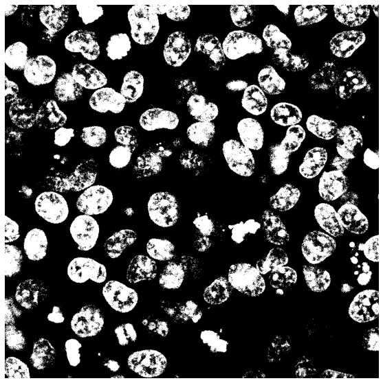

```python
fig, ax = plt.subplots(1,1,figsize=(10,10))
ax.imshow(Thresholded, cmap='gray')
ax.axis('off');
```

How to improve this? Let's do some pre-processing before thresholding.

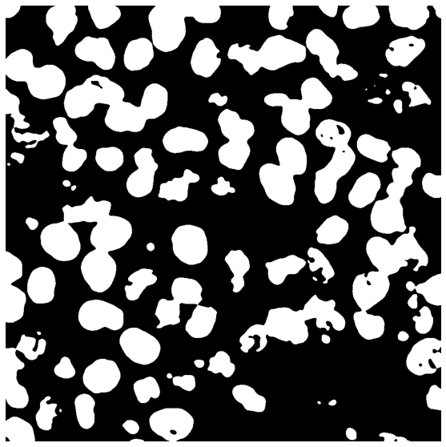

```python
Gauss = gaussian(channel_1, sigma=5)
Thresholded = Gauss > threshold_otsu(Gauss) # make sure you apply the Otsu to the Gaussian filtered image!
fig, ax = plt.subplots(1,1,figsize=(10,10))
ax.imshow(Thresholded, cmap='gray')
ax.axis('off');
```

This looks much better! The Gaussian filter removed the noise, so the Otsu threshold yields much more continuous objects! But still we have a lot of little objects that are probably not cells, and some of our cells have 'holes'. Luckily there are methods that can easily help with that.

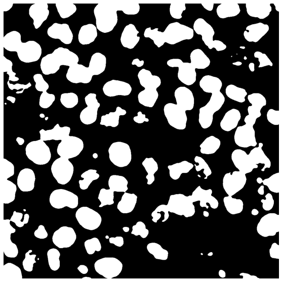

```python
Holes_removed = remove_small_holes(Thresholded, area_threshold = 512)
fig, ax = plt.subplots(1,1,figsize=(10,10))
ax.imshow(Holes_removed, cmap='gray')
ax.axis('off');
```

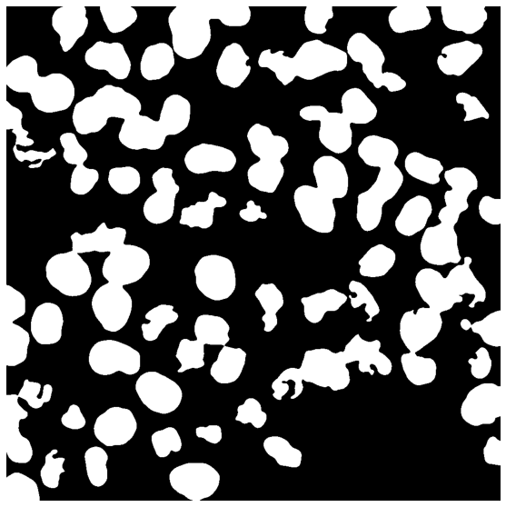

```python
Small_objects_removed = remove_small_objects(Holes_removed, min_size = 1024)
fig, ax = plt.subplots(1,1,figsize=(10,10))
ax.imshow(Small_objects_removed, cmap='gray')
ax.axis('off');
```

You may have to play around with the `area_threshold` and `min_size` parameters to get the desired effect. This depends heaviliy on your data, camera format, pixel size, etc. But for a simple combination of filters I think the result is already very good! One problem remains, we have quite some touching cells that would be considered by a segmentation algorithm as one object. How do we split them? We will talk about this more once we get to *Segmentation*.

However, one approach are *Morphological filters* that typically work on binary (boolean, black/white) images. To understand how those filters work, let's just have a look at a part of the image.

```python
Image_slice = Small_objects_removed[slice(250,350),slice(80,180)]
```

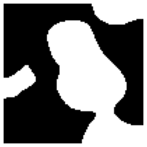

```python
fig, ax = plt.subplots(1,1,figsize=(5,5))
ax.imshow(Image_slice, cmap='gray')
ax.axis('off');
```

Let's run 4 common morphological operations, `dilation`, `erosion`, `closing`, `opening`.

The scikit-image version of these filters uses a **structuring element** to apply the algorithm. This can for example be a round area. We can use the function `disk` for this purpose.

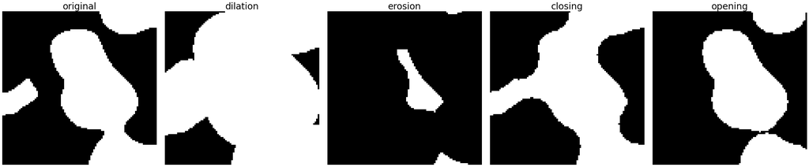

```python
morphological_filters = [dilation, erosion, closing, opening]
parameters = [disk(13), disk(13), disk(13), disk(13)]
fig, ax = plt.subplots(1,len(morphological_filters)+1,figsize=((len(morphological_filters)+1)*7, 7))
ax[0].imshow(Image_slice, cmap='gray')
ax[0].axis('off')
ax[0].set_title('original')
ax[0].title.set_size(28)
i=1
for morphological_filter, parameter in zip(morphological_filters, parameters):
    filtered = morphological_filter(Image_slice, parameter)
    ax[i].imshow(filtered, cmap='gray')
    ax[i].axis('off')
    ax[i].set_title(morphological_filter.__name__)
    ax[i].title.set_size(28)
    i=i+1
plt.tight_layout()
```

Note how dilation and erosion change the area of the thresholded objects whereas closing and opening roughly aim to keep the area but are effective in connecting objects ('closing') or breaking up objects ('opening'). So the latter would already be a good approach to separate touching cells! However, we would have to manually determine the optimal parameter for the 'opening' structural element for every data set.